# jw_treejoin-vis

James Waterford

2023-04-27

## Bioconductor

There a handful of databses for hosting biological software in R. The most famous is **CRAN**, but another very reliable source is **Bioconductor**.

When we are installing packages from CRAN, we use the function `install.packages()`.

To install packages from BioConductor, we use a function from an R package that is called `BiocManager` with the code `install.packages("BiocManager")`.

Now we will need to `library(BiocManager)`, we can now install packages directly from **Bioconductor**.

We do this with `install()`

## GG_tree

The package `gg_tree` is an extension of `ggplot2`. Specifically, it used for the visualiztion of phyolgenetic trees.

[output not shown]

```
##
Progress [----------------------------------] 0/12 (  0) ?s
Progress [================================] 12/12 (100)  0s
```

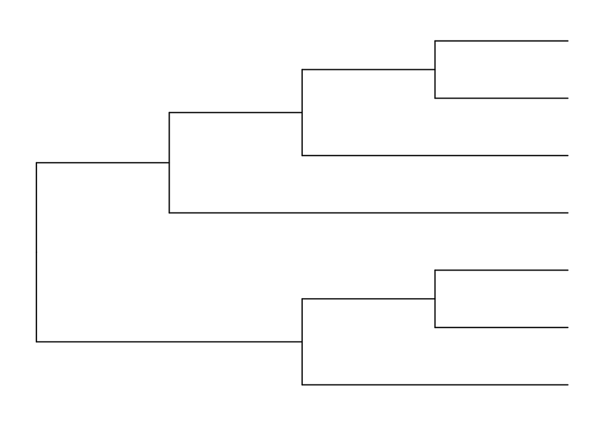

```r
 serpentes <- c("Gerrhopilidae",    "Anomalepididae", "Leptotyphlopidae", "Typhlopidae", "Loxocemidae", "Cylindrophiidae", "Bolyeridae","Aniliidae", "Boidae", "Tropidophiidae","Xenopeltidae", "Anomochilidae", "Uropeltidae", "Pythonidae", "Elapidae", "Pareatidae", "Lamprophiidae", "Viperidae",
"Colubridae", "Hydrophiidae",
"Xenodermatidae", "Dipsadidae",
"Homalopsidae", "Acrochordidae")
snake_taxa <- tnrs_match_names(serpentes)
snake_taxa
```

```
##       search_string      unique_name approximate_match  ott_id is_synonym flags
## 1     gerrhopilidae    Gerrhopilidae             FALSE 5839469      FALSE
## 2    anomalepididae   Anomalepididae             FALSE  886769      FALSE
## 3  leptotyphlopidae Leptotyphlopidae             FALSE  100033      FALSE
## 4       typhlopidae      Typhlopidae             FALSE  100036      FALSE
## 5       loxocemidae      Loxocemidae             FALSE  141674      FALSE
## 6   cylindrophiidae  Cylindrophiidae             FALSE  234192      FALSE
## 7        bolyeridae       Bolyeridae             FALSE 1021982      FALSE
## 8         aniliidae        Aniliidae             FALSE  496068      FALSE
## 9            boidae           Boidae             FALSE  186830      FALSE
## 10   tropidophiidae   Tropidophiidae             FALSE 1068482      FALSE
## 11     xenopeltidae     Xenopeltidae             FALSE  323409      FALSE
## 12    anomochilidae    Anomochilidae             FALSE  431355      FALSE
## 13      uropeltidae      Uropeltidae             FALSE 1068483      FALSE
## 14       pythonidae       Pythonidae             FALSE  897903      FALSE
```

[output cut: 35 more lines]

```r
snake_tr <- tol_induced_subtree(ott_ids = snake_taxa$ott_id)
```

```
##
Progress [----------------------------------] 0/22 (  0) ?s
Progress [================================] 22/22 (100)  0s
```

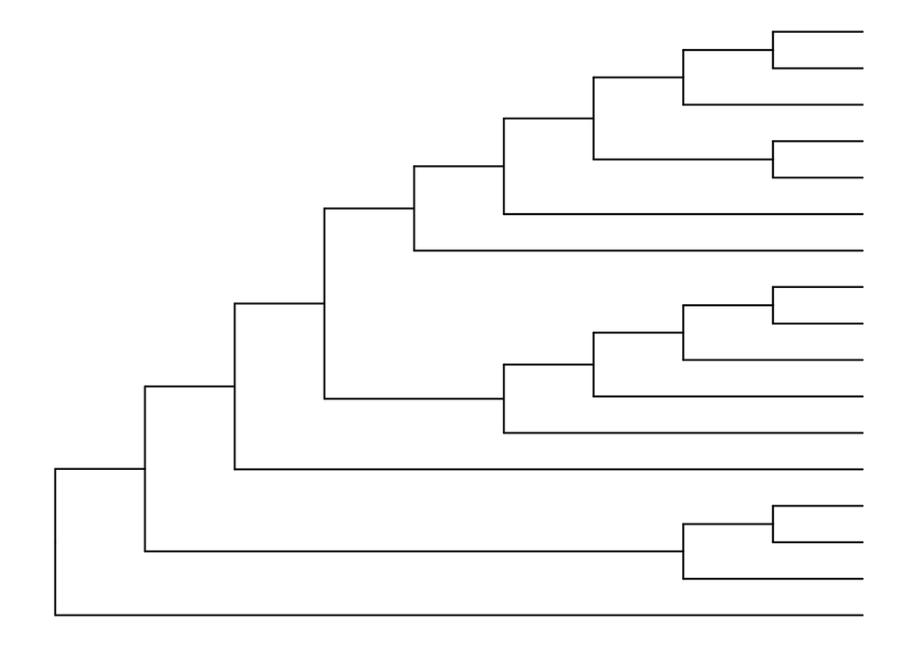

```r
ggtree(snake_tr)
```

## The structure of a tree in R

We have an object that we named `snake_tr`. However, this phylogenetic tree tells us, quite literally, nothing. At least not on the surface level, with the information that we put in.

We will use the `str()` command to get a deeper look.

```r
str(snake_tr)
```

```
## List of 4
##  $ edge      : int [1:32, 1:2] 24 23 30 30 29 27 26 32 33 33 ...
##  $ tip.label : chr [1:17] "mrcaott4565ott582937" "mrcaott17471ott30570" "Homalopsidae_ott1030676" "Viperidae_ott262303" ...
##  $ Nnode     : num 16
##  $ node.label: chr [1:16] "Serpentes ott186816" "mrcaott1662ott20148" "mrcaott1662ott35603" "mrcaott1662ott16254" ...
##  - attr(*, "class")= chr "phylo"
```

```r
snake_tr$node.label
```

```
##  [1] "Serpentes ott186816"    "mrcaott1662ott20148"    "mrcaott1662ott35603"
##  [4] "mrcaott1662ott16254"    "mrcaott1662ott215727"   "mrcaott1662ott6519"
##  [7] "mrcaott1662ott49551"    "mrcaott1662ott2991"     "mrcaott16254ott1021984"
## [10] "mrcaott16254ott58974"   "mrcaott16254ott231558"  "mrcaott16254ott323406"
## [13] "mrcaott16254ott840470"  "mrcaott231558ott431364" "mrcaott20148ott56992"
## [16] "mrcaott56992ott57008"
```

A *tip* represents a species at the current end of the phylogenetics tree.

A *node* is an interior branching point, where a previously named ancestor exists.

We are now going to install **aplot**.

`install.packages(aplot)`

Let’s combine a taxonomy in another data set

```r
library(dplyr)
taxonomy <- read.csv("../197-raw_storage/portal-species-taxonomy.csv")

surveys <- read.csv("../197-raw_storage/practice_data/surveys.csv")

intersect(colnames(taxonomy),colnames(surveys))
```

```
## [1] "species_id"
```

```r
joined <- inner_join(taxonomy,surveys, by = "species_id")
head(joined)
```

```
##                  label species_id      genus   species taxa
## 1 Amphispiza_bilineata         AB Amphispiza bilineata Bird
## 2 Amphispiza_bilineata         AB Amphispiza bilineata Bird
## 3 Amphispiza_bilineata         AB Amphispiza bilineata Bird
## 4 Amphispiza_bilineata         AB Amphispiza bilineata Bird
## 5 Amphispiza_bilineata         AB Amphispiza bilineata Bird
## 6 Amphispiza_bilineata         AB Amphispiza bilineata Bird
##               ott_name approximate_match ott_id is_synonym flags record_id
## 1 Amphispiza bilineata             FALSE 292646      FALSE            3126
## 2 Amphispiza bilineata             FALSE 292646      FALSE            3146
## 3 Amphispiza bilineata             FALSE 292646      FALSE            3152
## 4 Amphispiza bilineata             FALSE 292646      FALSE            3153
## 5 Amphispiza bilineata             FALSE 292646      FALSE            3586
## 6 Amphispiza bilineata             FALSE 292646      FALSE            3702
##   month day year plot_id sex hindfoot_length weight
## 1     7  21 1980       8                  NA     NA
## 2     7  21 1980      24                  NA     NA
## 3     7  21 1980      19                  NA     NA
## 4     7  21 1980      22                  NA     NA
## 5    12  15 1980      16                  NA     NA
## 6     1  11 1981      22                  NA     NA
```